# DAS. Final Project

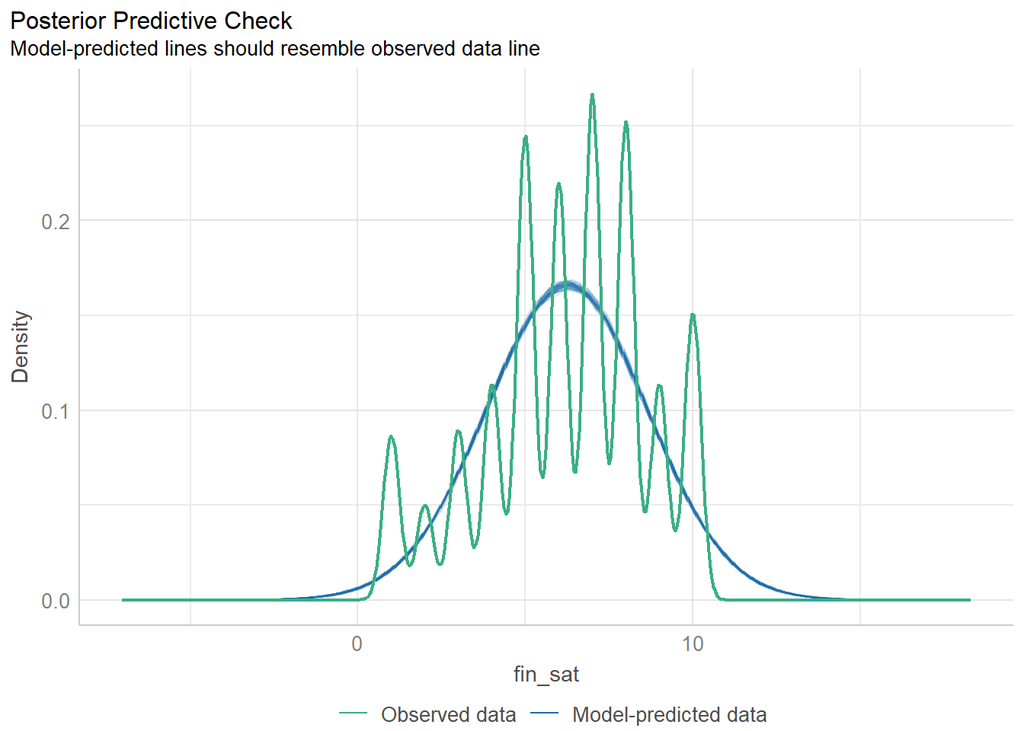

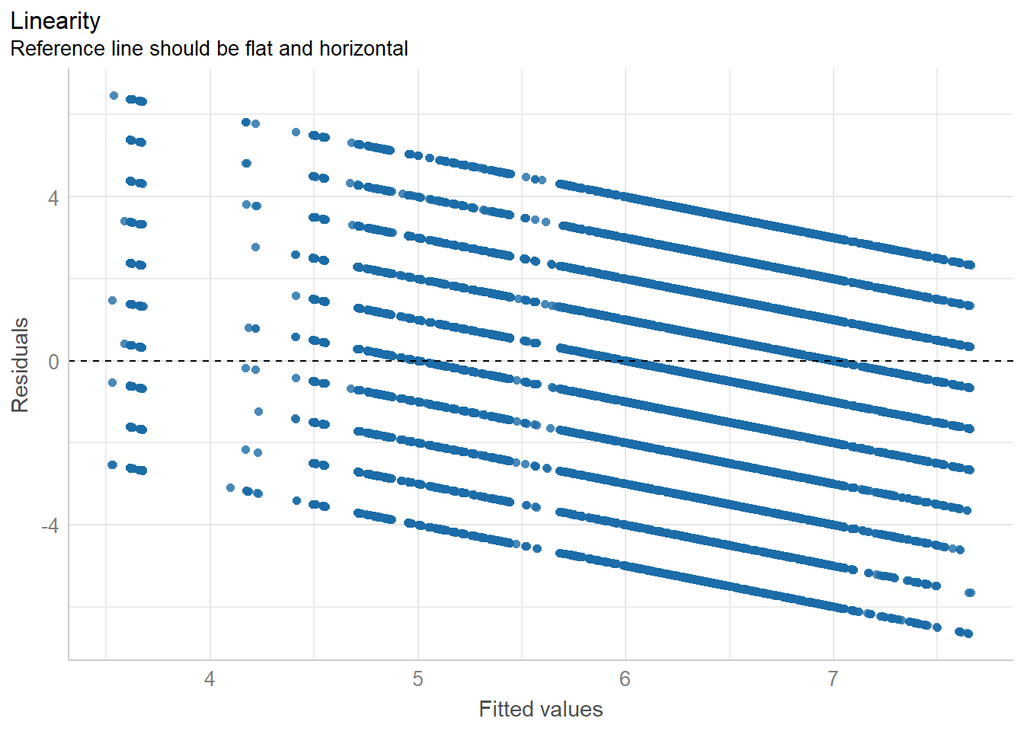

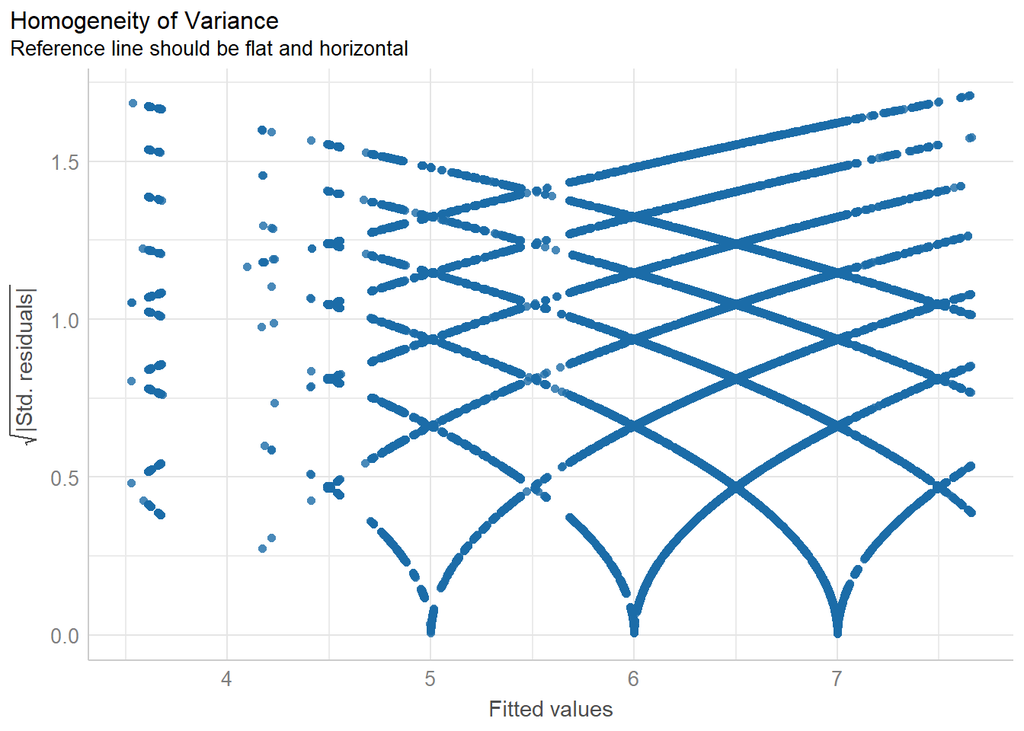

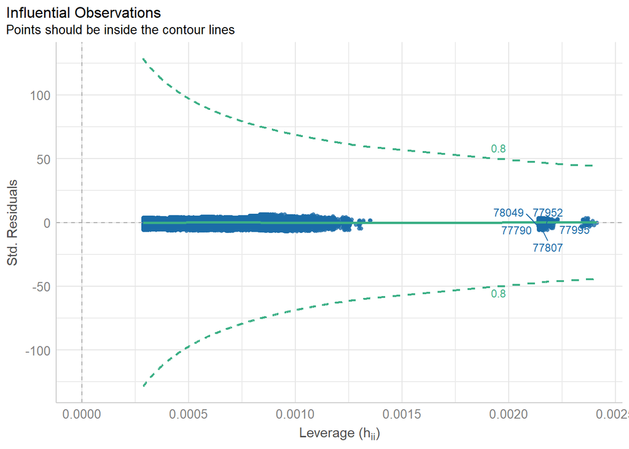

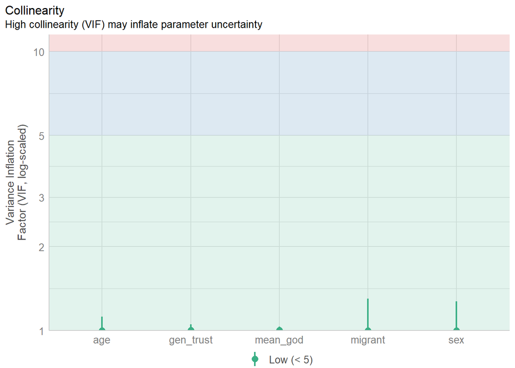

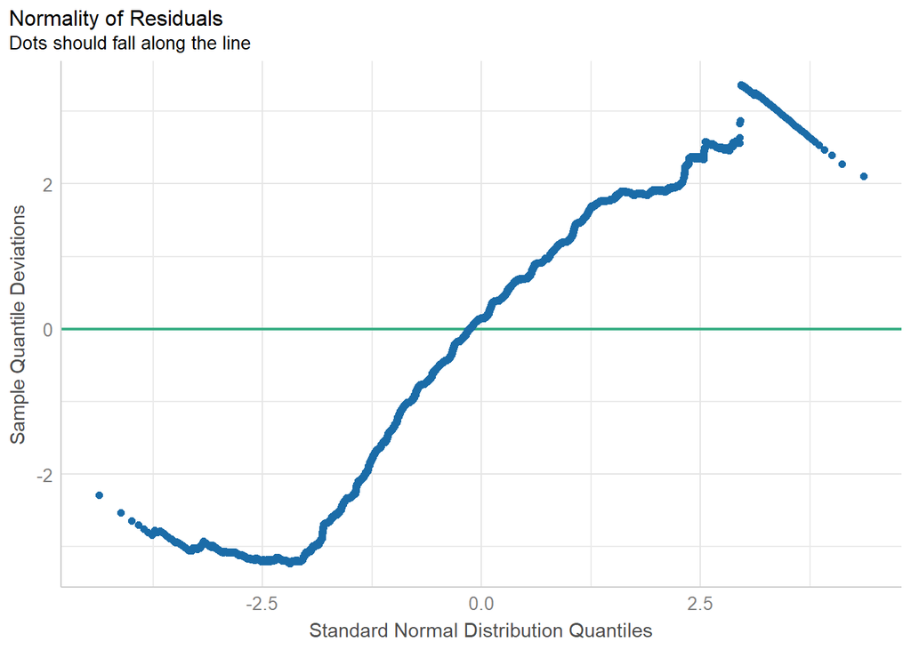

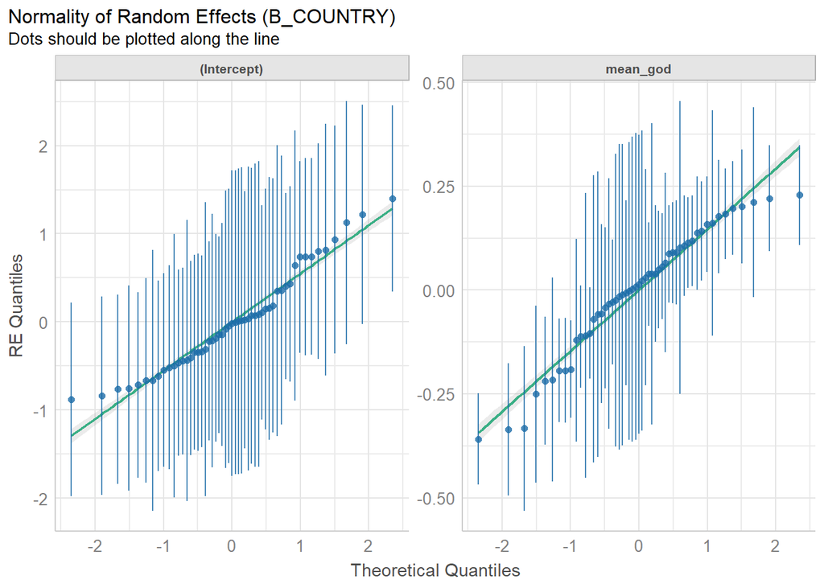

```r
graph <- performance::check_model(model4, panel = F, verbose = T)
plot(graph)
```

Here we have 7 different plots to diagnose our model, so let’s analyse it one by one.

1. This plot shows us the distributions of observed data and model-predicted data. The latest really tries to resemble the initial data, however it turns out to be not so good, because the outcome variable is a scale from 1 to 10 without some decimal points. In general, it’s not the worst scenario we could obtain.
2. This plot shows linearity. It is not very bad.
3. This plot shows homogeneity of variance. It could be better, but it is what it is.
4. This plot describes leverages. We can say that there are not so many leverages, that’s good.
5. This plot shows whether we have multicolinearity among our predictors. Great news - we do not have it!
6. This plot describes the normality of residuals. Though dots do not follow the green line, we may assume that for multilevel modelling it is a fine situation (according to Yaroslav Snarskiy, it is ok).
7. This graph shows the normality of random effects, and we can see that in this case dots follow the lines, that means that we have justified the usage of multilevel modelling with these variables (mean God importance and country).

## Model Building (3)

Now let’s check the random effects for the variables of the first level. If we find such an effect, we will add a cross-level interaction (1st x 2nd level predictors). If not – we will add an interaction between the 1st level predictors only.

#### Random Effects for 1st LVL Variables

We will check 3 individual variables as a random effect.

```r
model7.1 <- lmer(fin_sat ~ sex + age + migrant + gen_trust + mean_god + (1 + mean_god + sex | B_COUNTRY), data = df_imp, REML = FALSE)
tab_model(model7.1)
```

|  | fin_sat |  |  |
| --- | --- | --- | --- |
| Predictors | Estimates | CI | p |
| (Intercept) | 7.34 | 6.85 – 7.84 | **<0.001** |
| sex [2] | -0.05 | -0.10 – 0.01 | 0.101 |
| age | 0.00 | -0.00 – 0.00 | 0.655 |
| migrant [2] | -0.09 | -0.16 – -0.02 | **0.014** |
| gen trust [2] | -0.56 | -0.60 – -0.52 | **<0.001** |
| mean god | -0.10 | -0.19 – -0.02 | **0.015** |
| Random Effects |  |  |  |
| σ<sup>2</sup> | 5.18 |  |  |
| τ<sub>00</sub> <sub>B_COUNTRY</sub> | 0.86 |  |  |
| τ<sub>11</sub> <sub>B_COUNTRY.mean_god</sub> | 0.04 |  |  |
| τ<sub>11</sub> <sub>B_COUNTRY.sex2</sub> | 0.02 |  |  |
| ρ<sub>01</sub> | -0.94 |  |  |
|  | -0.18 |  |  |
| ICC | 0.09 |  |  |
| N <sub>B_COUNTRY</sub> | 53 |  |  |
| Observations | 78069 |  |  |
| Marginal R<sup>2</sup> / Conditional R<sup>2</sup> | 0.023 / 0.115 |  |  |

Model with sex as a random effect shows us that sex is no longer significant, so we will not proceed with interaction here.

```r
model7.2 <- lmer(fin_sat ~ sex + age + migrant + gen_trust + mean_god + (1 + mean_god + migrant | B_COUNTRY), data = df_imp, REML = FALSE)
tab_model(model7.2)
```

|  | fin_sat |  |  |
| --- | --- | --- | --- |
| Predictors | Estimates | CI | p |
| (Intercept) | 7.31 | 6.81 – 7.81 | **<0.001** |
| sex [2] | -0.05 | -0.08 – -0.01 | **0.004** |
| age | 0.00 | -0.00 – 0.00 | 0.706 |
| migrant [2] | -0.13 | -0.27 – 0.01 | 0.073 |
| gen trust [2] | -0.56 | -0.60 – -0.52 | **<0.001** |
| mean god | -0.10 | -0.18 – -0.01 | **0.021** |
| Random Effects |  |  |  |
| σ<sup>2</sup> | 5.19 |  |  |
| τ<sub>00</sub> <sub>B_COUNTRY</sub> | 0.88 |  |  |
| τ<sub>11</sub> <sub>B_COUNTRY.mean_god</sub> | 0.04 |  |  |
| τ<sub>11</sub> <sub>B_COUNTRY.migrant2</sub> | 0.10 |  |  |
| ρ<sub>01</sub> | -0.94 |  |  |
|  | -0.51 |  |  |
| ICC | 0.09 |  |  |
| N <sub>B_COUNTRY</sub> | 53 |  |  |
| Observations | 78069 |  |  |
| Marginal R<sup>2</sup> / Conditional R<sup>2</sup> | 0.022 / 0.113 |  |  |

Model with migrant status as a random effect shows us that migrant status is now insignificant.

```r
model7.3 <- lmer(fin_sat ~ sex + age + migrant + gen_trust + mean_god + (1 + mean_god + gen_trust | B_COUNTRY), data = df_imp, REML = FALSE)
tab_model(model7.3)
```

|  | fin_sat |  |  |
| --- | --- | --- | --- |
| Predictors | Estimates | CI | p |
| (Intercept) | 7.06 | 6.60 – 7.52 | **<0.001** |
| sex [2] | -0.05 | -0.08 – -0.01 | **0.004** |
| age | 0.00 | -0.00 – 0.00 | 0.837 |
| migrant [2] | -0.07 | -0.14 – -0.00 | **0.038** |
| gen trust [2] | -0.45 | -0.56 – -0.35 | **<0.001** |
| mean god | -0.08 | -0.16 – -0.01 | **0.027** |
| Random Effects |  |  |  |
| σ<sup>2</sup> | 5.17 |  |  |
| τ<sub>00</sub> <sub>B_COUNTRY</sub> | 1.24 |  |  |
| τ<sub>11</sub> <sub>B_COUNTRY.mean_god</sub> | 0.04 |  |  |
| τ<sub>11</sub> <sub>B_COUNTRY.gen_trust2</sub> | 0.11 |  |  |
| ρ<sub>01</sub> | -0.91 |  |  |
|  | -0.93 |  |  |
| ICC | 0.10 |  |  |
| N <sub>B_COUNTRY</sub> | 53 |  |  |
| Observations | 78069 |  |  |
| Marginal R<sup>2</sup> / Conditional R<sup>2</sup> | 0.015 / 0.114 |  |  |

Model with general trust as a random effect shows us that general trust is still significant, so we will proceed with interaction in this case.

```r
anova(model4, model7.3)
```

|  | npar | AIC | BIC | logLik | deviance | Chisq | Df | Pr(>Chisq) |
| --- | --- | --- | --- | --- | --- | --- | --- | --- |
| model4 | 10 | 350404.4 | 350497.1 | -175192.2 | 350384.4 | NA | NA | NA |
| model7.3 | 13 | 350203.7 | 350324.2 | -175088.9 | 350177.7 | 206.7223 | 3 | 1.487757e-44 |

Besides, this model is better than the mdoel without usage general trust as a random effect, based on ANOVA test.

#### Interactions

Let’s proceed to the interaction models.

```r
model8.1 <- lmer(fin_sat ~ sex + age + migrant + mean_god*gen_trust + (1 + mean_god + gen_trust | B_COUNTRY), data = df_imp, REML = FALSE)
tab_model(model8.1)
```

|  | fin_sat |  |  |
| --- | --- | --- | --- |
| Predictors | Estimates | CI | p |
| (Intercept) | 7.55 | 6.98 – 8.11 | **<0.001** |
| sex [2] | -0.05 | -0.08 – -0.01 | **0.004** |
| age | 0.00 | -0.00 – 0.00 | 0.845 |
| migrant [2] | -0.07 | -0.14 – -0.00 | **0.039** |
| mean god | -0.14 | -0.23 – -0.06 | **0.001** |
| gen trust [2] | -0.95 | -1.27 – -0.63 | **<0.001** |
| mean god × gen trust [2] | 0.07 | 0.03 – 0.11 | **0.002** |
| Random Effects |  |  |  |
| σ<sup>2</sup> | 5.17 |  |  |
| τ<sub>00</sub> <sub>B_COUNTRY</sub> | 1.17 |  |  |
| τ<sub>11</sub> <sub>B_COUNTRY.mean_god</sub> | 0.04 |  |  |
| τ<sub>11</sub> <sub>B_COUNTRY.gen_trust2</sub> | 0.08 |  |  |
| ρ<sub>01</sub> | -0.92 |  |  |
|  | -0.91 |  |  |
| N <sub>B_COUNTRY</sub> | 53 |  |  |
| Observations | 78069 |  |  |
| Marginal R<sup>2</sup> / Conditional R<sup>2</sup> | 0.021 / NA |  |  |

We can see the interaction effect in case of using general trust variable. Let’s describe this model in details.

```r
anova(model4, model8.1)
```

|  | npar | AIC | BIC | logLik | deviance | Chisq | Df | Pr(>Chisq) |
| --- | --- | --- | --- | --- | --- | --- | --- | --- |
| model4 | 10 | 350404.4 | 350497.1 | -175192.2 | 350384.4 | NA | NA | NA |
| model8.1 | 14 | 350197.6 | 350327.3 | -175084.8 | 350169.6 | 214.8131 | 4 | 2.448959e-45 |

Moreover, based on ANOVA test, this model is better than the model without interaction effect and usage of general trust as a random effect.

## Model Diagnostics (3)

Predictors:

- The intercept is 7.55, indicating the average financial satisfaction of household level when all other predictors are at 0.
- Sex has a negative effect with an estimate of -0.05.
- Age has no statistically significant effect.
- Migrant has a negative effect with an estimate of -0.07.
- Mean God importance has a negative effect with an estimate of -0.14.
- General trust has a negative effect with an estimate of -0.95.
- The interaction term mean God importance * general trust has a positive effect with an estimate of 0.07.

Random Effects:

- The variance is 5.17.
- The random intercept for the variable “B_COUNTRY” has a variance of 1.17.
- The random slope for mean God importance within B_COUNTRY has a variance of 0.04.
- The random slope for general trust within B_COUNTRY has a variance of 0.08.
- The correlation between the random intercept and slope is -0.92.

Other:

- The Marginal R2 is 0.021, indicating that the fixed effects explain 2.1% of the variance in financial satisfaction of household level

Interpretation:

- The model suggests that sex, migrant status, mean God importance, general trust, and the interaction between mean God importance and general trust have significant effects on financial satisfaction of household level.
- The random intercepts and slopes for mean God importance and general trust within B_COUNTRY capture additional variability in financial satisfaction of household level.
- The negative correlation between the random intercept and slope suggests that countries with higher intercepts tend to have lower slopes for the predictors mean God importance and general trust.

# 5. Conceptual interpretation of the results of the analysis.

## MLM with Random Intercept (1)

The model’s findings provide valuable insights into the complex interplay between sociological factors and financial satisfaction.

- The negative coefficient for sex highlights the gender disparities in financial satisfaction, with females experiencing slightly lower levels of satisfaction compared to males. This aligns with sociological theories that emphasize the impact of gender socialization, occupational segregation, and unequal access to resources on economic outcomes.
- The negative coefficient for migrant status sheds light on the challenges faced by individuals who have migrated to a new country. Migration involves navigating unfamiliar social networks, institutions, and economic opportunities, which can contribute to lower financial satisfaction levels. This underscores the importance of considering the intersectionality of factors such as ethnicity, nationality, and migration status in understanding economic disparities.
- The negative coefficient for general trust points to the role of social capital in shaping economic well-being. Individuals with lower levels of trust in others may struggle to establish supportive social networks, access resources, and navigate economic opportunities, thereby impacting their financial satisfaction. This reflects sociological perspectives on the significance of social cohesion, trust, and reciprocity in shaping economic outcomes.
- The random effects analysis reveals the variation in financial satisfaction levels across different countries, indicating the influence of broader societal contexts on individual economic well-being. This highlights the importance of considering macro-level factors such as cultural norms, economic policies, and institutional structures in understanding and addressing economic inequalities.

Overall, the model underscores the multidimensional nature of financial satisfaction within a sociological framework, emphasizing the interconnectedness of individual characteristics, social dynamics, and structural factors in shaping economic well-being. Understanding these complex relationships is crucial for addressing systemic inequalities and promoting financial well-being across diverse sociological contexts.

## MLM with Random Slope (2)

This model examines the relationship between various sociological factors and financial satisfaction with random slope.

- The negative coefficient for sex suggests that gender plays a role in financial satisfaction, with females tending to have slightly lower satisfaction levels compared to males. This reflects broader gender inequalities in access to resources and financial security.
- The negative coefficient for migrant status indicates that migrants experience lower financial satisfaction than non-migrants. This speaks to the challenges faced by individuals in adapting to new environments and accessing resources in their host countries.
- The negative coefficient for general trust highlights the importance of social capital in economic well-being. Individuals with lower levels of trust in others may struggle to navigate financial opportunities and support systems.
- The negative coefficient for belief in a higher power hints at the complex interplay between spirituality and financial satisfaction. This may reflect the influence of religious values on economic behaviors and outcomes.
- The random effects show how financial satisfaction varies across countries. The relationship between country-level factors and individual financial satisfaction underscores the impact of broader societal contexts on economic well-being.
- No educational nor political effects were observed. Thus, our hypotheses have not been confirmed regarding them.
- Overall, the model underscores the multidimensional nature of financial satisfaction, shaped by individual characteristics, social dynamics, and broader structural factors. Understanding these dynamics is essential for addressing economic inequalities and promoting well-being in diverse sociological contexts.

## MLM with Interaction Efefct (3)

From a sociological perspective, the findings of this model can be interpreted in terms of how individual characteristics and societal factors impact financial satisfaction.

Overall, the model’s findings point to the complex interplay between individual characteristics, societal norms, and structural inequalities in shaping financial satisfaction. Understanding these dynamics from a sociological perspective can provide insights into how social factors influence economic outcomes and inequality.